# Machine Learning

### Topic "Desicion regression tree with linear model"

Import the necessary libraries

```python
from sklearn.metrics import mean_squared_error
import pandas as pd
import numpy as np
from sklearn.compose import ColumnTransformer
from sklearn.preprocessing import OneHotEncoder
from sklearn.model_selection import train_test_split
from sklearn.tree import DecisionTreeRegressor
from sklearn.linear_model import Ridge
```

#### Datasets

For test we use 5 datasets from the UC Irvine Machine Learning Repository

```python
# Dataset №1
# Forest Fires Data Set
# https://archive.ics.uci.edu/ml/datasets/Forest+Fires
path_dataset_1='forestfires1.csv'

# Dataset №2
# Wine Quality Data Set
# https://archive.ics.uci.edu/ml/datasets/Wine+Quality
path_dataset_2='winequality-red.csv'

# Dataset №3
# Appliances energy prediction Data Set
# https://archive.ics.uci.edu/ml/datasets/Appliances+energy+prediction
path_dataset_3='energydata_complete.csv'

# Dataset №4
# Electrical Grid Stability Simulated Data Data Set
# https://archive.ics.uci.edu/ml/datasets/Electrical+Grid+Stability+Simulated+Data+
path_dataset_4='Data_for_UCI_named.csv'


# Dataset №5
# Physicochemical Properties of Protein Tertiary Structure Data Set
# https://archive.ics.uci.edu/ml/datasets/Physicochemical+Properties+of+Protein+Tertiary+Structure
path_dataset_5='CASP.csv'
```

Time to coding

#### Create Tree

```python
class Root_Node:
    def __init__(self, df,target):
        self.df = df
        self.size=df.shape[0]
        self.target=target
        self.size=self.df.shape[0]
        self.categorical_mask = (self.df.dtypes == object)
        self.categorical_features=self.df.columns[self.categorical_mask].to_list()
        self.all_features=self.df.columns.to_list()
        self.all_features.remove(target)
        self.children='no'

# preproc:drop row with categorical NaN
    def preproc(self):
#         self.df=self.df.fillna(self.df.mean())
        self.df=self.df.dropna(how='any')
        self.size=self.df.shape[0]

# log: include preprocessing, dummies and learning Ridge Regression
    def log(self,df):
        Y=df[[self.target]]
        D=df.drop(self.target,axis=1)
        koefD=D.shape[0]/self.size
        ridge = Ridge(normalize=True)
        categorical_mask = (D.dtypes == object)
        to_drop = D.columns[categorical_mask]
        categorical_features=D.columns[categorical_mask].to_list()
        transformer = ColumnTransformer(transformers=[("OneHot",OneHotEncoder(sparse=False),categorical_mask)])
        X=transformer.fit_transform(D)
        X=pd.DataFrame(X)
        X.reset_index(drop=True, inplace=True)
        D.reset_index(drop=True, inplace=True)
        D = pd.concat([D, X], axis=1)
        D=D.drop(to_drop,axis=1)
        model=ridge.fit(D,Y)

        metric=mean_squared_error(Y, model.predict(D))*koefD
        return (metric,model,transformer)

# fit: iterates over all separation options, selects split with the best MSE ,
#     the operation is performed recursively until the size of the dataframe's split is more than size_n
    def fit(self,size_n=100):
        self.metric,self.model,self.transformer= self.log(self.df)
        if self.size<size_n:
            return self.metric,self.model
        r=10000000000
        for feature in self.all_features:
            values=self.df[feature].unique()
            if feature in self.categorical_features:
                array=[]
                for value in values:
                    df_new=self.df[self.df[feature]==value]
                    score=self.log(df_new)
                    array.append(score[0])
                score=np.sum(array)
                if score<r:
                    r=score
                    rmse=[score,feature]
#             if True:
            else:
                values_min=np.amin(values)
                values_max=np.amax(values)
                values=np.linspace(values_min, values_max, num=10)
#                 print((values))
                for value in values:
                    df_new1,df_new2=self.df[self.df[feature]>=value],self.df[self.df[feature]<value]
                    if df_new1.shape[0]>10 and df_new2.shape[0]>10:
                        score1=self.log(df_new1)[0]
                        score2=self.log(df_new2)[0]
                        score=score1+score2
                        if score<r:
                            r=score
                            rmse=[score,feature,value]

        if len(rmse)==2:
            ar=[]
            for value in self.df[rmse[1]].unique():
                ar.append((Root_Node(self.df[self.df[rmse[1]]==value],self.target),value))
            self.children=[ar,rmse[1],'Category']
        elif len(rmse)==3:
            df11=[Root_Node(self.df[self.df[rmse[1]]>=rmse[2]],self.target),'>=']
            df22=[Root_Node(self.df[self.df[rmse[1]]<rmse[2]],self.target),'<']
            self.children=[df11,df22,rmse[1],rmse[2],'Numeric']

        if self.children[2]=='Category':
            for i in self.children[0]:
                i[0].fit()
        elif self.children[4]=='Numeric':
            self.children[0][0].fit()
            self.children[1][0].fit()

# search: search sub-DataFrame to every row from Test DataFrame, return its object
    def search(self,df_new):
        if self.children=='no':
            return self
        else:
            if self.children[2]=='Category':
                for i in range(len(self.children[0])):
                    value=self.children[0][i][1]
                    feature=self.children[1]
                    node=self.children[0][i][0]
                    if df_new[feature].tolist()[0]==value:
                        return node.search(df_new)
            elif self.children[4]=='Numeric':
                value=self.children[3]
                feature=self.children[2]
                if df_new[feature].tolist()[0]>=value:
                    node=self.children[0][0]
                else:
                    node=self.children[1][0]
                return node.search(df_new)

# predict: transform Test DataSet and predict value according to its Sub DataFrame model
    def predict(self,df_new):
        df_new=df_new.dropna(how='any')
        y_p=[]
        y_t=[]
        for i in range(df_new.shape[0]):
            test_df=df_new.iloc[[i],:]
            node=self.search(test_df)
            y_test=test_df[self.target]
            categorical_mask = (test_df.dtypes == object)
            to_drop = test_df.columns[categorical_mask]
            test_df=test_df.drop(self.target,axis=1)
            try:
                X=node.transformer.transform(test_df)
                X=pd.DataFrame(X)
                model=node.model
                X.reset_index(drop=True, inplace=True)
                test_df.reset_index(drop=True, inplace=True)
                test_df = pd.concat([test_df, X], axis=1)
                test_df=test_df.drop(to_drop,axis=1)
                y_pred=model.predict(test_df)[0][0]
                y_pred=round(y_pred,2)
                y_t.append(y_test.values[0])
                y_p.append(y_pred)
            except:
                continue
        return pd.DataFrame({'Y_test':y_t,'Y_pred':y_p})
```

#### Function DecisionTreeRegressor from SkLearn

Small function to preprocessing and learning with DecisionTreeRegressor from SkLearn

```python
def proc_learn(BigData,target_label,Train,Holdout):
    BigData=DataSet.dropna(how='any')
    categorical_mask = (BigData.dtypes == object)
    to_drop = BigData.columns[categorical_mask]
    categorical_features=BigData.columns[categorical_mask].to_list()
    transformer = ColumnTransformer(transformers=[("OneHot",OneHotEncoder(sparse=False),categorical_mask)])
    X=transformer.fit_transform(BigData)
    X=pd.DataFrame(X)
    X.reset_index(drop=True, inplace=True)
    BigData.reset_index(drop=True, inplace=True)
    BigData = pd.concat([BigData, X], axis=1)
    BigData=BigData.drop(to_drop,axis=1)
    new_train = BigData[BigData.index.isin(Train.index)]
    new_test = BigData[BigData.index.isin(Holdout.index)]
    train_x=new_train.drop(target_label,axis=1)
    train_y=new_train[target_label]
    test_x=new_test.drop(target_label,axis=1)
    test_y=new_test[target_label]
    model=DecisionTreeRegressor()
    model.fit(train_x,train_y)
    y_pred=model.predict(test_x)
    metric=mean_squared_error(test_y, y_pred)
    metric=round(metric,2)
    return (pd.DataFrame({'Y_test':test_y,'Y_predict':y_pred}),metric)
```

Time for testing code

#### DataSet №1

Read dataset Target to predict here it is 'temp'

```python
# temp - temperature in Celsius degrees
target_label='temp'
DataSet=pd.read_csv(path_dataset_1)
DataSet.head()
```

|  | X | Y | month | day | FFMC | DMC | DC | ISI | temp | RH | wind | rain | area |
| --- | --- | --- | --- | --- | --- | --- | --- | --- | --- | --- | --- | --- | --- |
| 0 | 7 | 5 | mar | fri | 86.2 | 26.2 | 94.3 | 5.1 | 8.2 | 51.0 | 6.7 | 0.0 | 0.0 |
| 1 | 7 | 4 | oct | tue | 90.6 | 35.4 | 669.1 | 6.7 | 18.0 | 33.0 | 0.9 | 0.0 | 0.0 |
| 2 | 7 | 4 | NaN | sat | 90.6 | 43.7 | 686.9 | 6.7 | NaN | NaN | 1.3 | 0.0 | 0.0 |
| 3 | 8 | 6 | mar | fri | 91.7 | 33.3 | 77.5 | 9.0 | 8.3 | 97.0 | 4.0 | 0.2 | 0.0 |
| 4 | 8 | 6 | mar | sun | 89.3 | 51.3 | 102.2 | 9.6 | 11.4 | 99.0 | 1.8 | 0.0 | 0.0 |

Split data for Train and Holdout

```python
Train,Holdout = train_test_split(DataSet, test_size=0.3,
random_state=17)
print('Rows:')
print('Train:{}'.format(Train.shape[0]))
print('Holdout:{}'.format(Holdout.shape[0]))
```

```
Rows:
Train:361
Holdout:156
```

#### First of all check MSE DecisionTreeRegressor from SkLearn

```python
df,metric=proc_learn(DataSet,target_label,Train,Holdout)
print('MSE with DecisionTreeRegressor from SkLearn:{}'.format(metric))
print("\nDataFrame's example:")
df.head()
```

```
MSE with DecisionTreeRegressor from SkLearn:12.32

DataFrame's example:
```

|  | Y_test | Y_predict |
| --- | --- | --- |
| 3 | 11.4 | 15.2 |
| 9 | 17.8 | 17.4 |
| 13 | 26.4 | 24.3 |
| 14 | 22.9 | 18.6 |
| 16 | 16.7 | 14.2 |

#### Now lets implement our algorithm

Create class object

```python
Tree_DataSet=Root_Node(Train,target_label)
print('NaN count')
Tree_DataSet.df.isnull().sum()
```

```
NaN count
```

```
X        0
Y        0
month    1
day      0
FFMC     0
DMC      0
DC       0
ISI      0
temp     1
RH       1
wind     0
rain     0
area     0
dtype: int64
```

Use method "preproc" to prerpocessing Drop rows with NaN categorial

```python
Tree_DataSet.preproc()
Tree_DataSet.df.isnull().sum()
```

```
X        0
Y        0
month    0
day      0
FFMC     0
DMC      0
DC       0
ISI      0
temp     0
RH       0
wind     0
rain     0
area     0
dtype: int64
```

Now we start learning procedure size_n - the number instanses in leaves

```python
Tree_DataSet.fit(size_n=40)
```

May check that build tree with childs

```python
Tree_DataSet.children
```

```
[[(<__main__.Root_Node at 0x152c864abe0>, 'sep'),
  (<__main__.Root_Node at 0x152c864a588>, 'jul'),
  (<__main__.Root_Node at 0x152c8625550>, 'feb'),
  (<__main__.Root_Node at 0x152c8625470>, 'jun'),
  (<__main__.Root_Node at 0x152c76131d0>, 'mar'),
  (<__main__.Root_Node at 0x152c76136d8>, 'aug'),
  (<__main__.Root_Node at 0x152c76135f8>, 'apr'),
  (<__main__.Root_Node at 0x152c8626400>, 'oct'),
  (<__main__.Root_Node at 0x152c8626320>, 'may'),
  (<__main__.Root_Node at 0x152c8626160>, 'dec'),
  (<__main__.Root_Node at 0x152c8626b00>, 'nov'),
  (<__main__.Root_Node at 0x152c86260f0>, 'jan')],
 'month',
 'Category']
```

Split Example: child with 'month'='sep'

```python
Tree_DataSet.children[0][0][0].df.head()
```

|  | X | Y | month | day | FFMC | DMC | DC | ISI | temp | RH | wind | rain | area |
| --- | --- | --- | --- | --- | --- | --- | --- | --- | --- | --- | --- | --- | --- |
| 86 | 1 | 2 | sep | thu | 92.9 | 137.0 | 706.4 | 9.2 | 25.4 | 27.0 | 2.2 | 0.0 | 0.00 |
| 392 | 1 | 3 | sep | sun | 91.0 | 276.3 | 825.1 | 7.1 | 21.9 | 43.0 | 4.0 | 0.0 | 70.76 |
| 108 | 4 | 5 | sep | sat | 92.5 | 88.0 | 698.6 | 7.1 | 20.3 | 45.0 | 3.1 | 0.0 | 0.00 |
| 338 | 8 | 6 | sep | mon | 91.6 | 108.4 | 764.0 | 6.2 | 22.7 | 35.0 | 2.2 | 0.0 | 7.48 |
| 225 | 4 | 4 | sep | sun | 93.5 | 149.3 | 728.6 | 8.1 | 22.9 | 39.0 | 4.9 | 0.0 | 48.55 |

Can see that the trained model is stored in every child

```python
Tree_DataSet.children[0][0][0].model
```

```
Ridge(alpha=1.0, copy_X=True, fit_intercept=True, max_iter=None,
   normalize=True, random_state=None, solver='auto', tol=0.001)
```

Now predict on Holdout dataframe

```python
df_prediction=Tree_DataSet.predict(Holdout)
df_prediction.head()
```

|  | Y_test | Y_pred |
| --- | --- | --- |
| 0 | 10.6 | 12.01 |
| 1 | 17.7 | 21.47 |
| 2 | 20.6 | 19.11 |
| 3 | 17.9 | 20.37 |
| 4 | 15.8 | 14.24 |

MSE our algorithm

```python
MSE_our=mean_squared_error(df_prediction['Y_test'],df_prediction['Y_pred'])
MSE_our=round(MSE_our,2)
print('MSE our alghoritm with linear model:{}'.format(MSE_our))
```

```
MSE our alghoritm with linear model:11.47
```

MSE of our algorithm for this dataset is better than MSE DecisionTreeRegressor from SkLearn 11.47 against 12.32

Note:less MSE is better

#### DataSet №2

```python
target_label='total sulfur dioxide'
DataSet=pd.read_csv(path_dataset_2,sep=';')
# DataSet=DataSet.drop('url',axis=1)
Train,Holdout = train_test_split(DataSet, test_size=0.3,
random_state=17)
DataSet.head()
```

|  | fixed acidity | volatile acidity | citric acid | residual sugar | chlorides | free sulfur dioxide | total sulfur dioxide | density | pH | sulphates | alcohol | quality |
| --- | --- | --- | --- | --- | --- | --- | --- | --- | --- | --- | --- | --- |
| 0 | 7.4 | 0.70 | 0.00 | 1.9 | 0.076 | 11.0 | 34.0 | 0.9978 | 3.51 | 0.56 | 9.4 | 5 |
| 1 | 7.8 | 0.88 | 0.00 | 2.6 | 0.098 | 25.0 | 67.0 | 0.9968 | 3.20 | 0.68 | 9.8 | 5 |
| 2 | 7.8 | 0.76 | 0.04 | 2.3 | 0.092 | 15.0 | 54.0 | 0.9970 | 3.26 | 0.65 | 9.8 | 5 |
| 3 | 11.2 | 0.28 | 0.56 | 1.9 | 0.075 | 17.0 | 60.0 | 0.9980 | 3.16 | 0.58 | 9.8 | 6 |
| 4 | 7.4 | 0.70 | 0.00 | 1.9 | 0.076 | 11.0 | 34.0 | 0.9978 | 3.51 | 0.56 | 9.4 | 5 |

```python
print('Rows:')
print('Train:{}'.format(Train.shape[0]))
print('Holdout:{}'.format(Holdout.shape[0]))
```

```
Rows:
Train:1119
Holdout:480
```

#### DecisionTreeRegressor from SkLearn

```python
df,metric=proc_learn(DataSet,target_label,Train,Holdout)
print('MSE with DecisionTreeRegressor from SkLearn:{}'.format(metric))
print('Example DataFrame')
df.head()
```

```
MSE with DecisionTreeRegressor from SkLearn:578.86
Example DataFrame
```

|  | Y_test | Y_predict |
| --- | --- | --- |
| 0 | 34.0 | 34.0 |
| 5 | 40.0 | 35.0 |
| 6 | 59.0 | 37.0 |
| 17 | 56.0 | 69.0 |
| 18 | 29.0 | 11.0 |

#### Our algorithm

```python
Tree_DataSet=Root_Node(Train,target_label)
Tree_DataSet.preproc()
Tree_DataSet.fit(size_n=200)
df_prediction=Tree_DataSet.predict(Holdout)
df_prediction.head()
```

|  | Y_test | Y_pred |
| --- | --- | --- |
| 0 | 47.0 | 47.12 |
| 1 | 15.0 | 22.24 |
| 2 | 13.0 | 16.01 |
| 3 | 99.0 | 62.06 |
| 4 | 79.0 | 59.30 |

```python
MSE_our=mean_squared_error(df_prediction['Y_test'],df_prediction['Y_pred'])
MSE_our=round(MSE_our,2)
print('MSE our alghoritm with linear model:{}'.format(MSE_our))
```

```
MSE our alghoritm with linear model:442.29
```

Small comment: The test of two algorithms passes on the same data set, although the order of the rows is different Demonstrate this:

```python
df_prediction['Y_test'].sum()
```

```
22758.0
```

```python
df['Y_test'].sum()
```

```
22758.0
```

MSE of our algorithm for this dataset is better than MSE DecisionTreeRegressor from SkLearn 442.29 against 578.86

### DataSet №3

```python
# Appliances, energy use in Wh
target_label='Appliances'
DataSet=pd.read_csv(path_dataset_3).drop('date',axis=1)
Train,Holdout = train_test_split(DataSet, test_size=0.3,
random_state=17)
DataSet.head()
```

|  | Appliances | lights | T1 | RH_1 | T2 | RH_2 | T3 | RH_3 | T4 | RH_4 | ... | T9 | RH_9 | T_out | Press_mm_hg | RH_out | Windspeed | Visibility | Tdewpoint | rv1 | rv2 |
| --- | --- | --- | --- | --- | --- | --- | --- | --- | --- | --- | --- | --- | --- | --- | --- | --- | --- | --- | --- | --- | --- |
| 0 | 60 | 30 | 19.89 | 47.596667 | 19.2 | 44.790000 | 19.79 | 44.730000 | 19.000000 | 45.566667 | ... | 17.033333 | 45.53 | 6.600000 | 733.5 | 92.0 | 7.000000 | 63.000000 | 5.3 | 13.275433 | 13.275433 |
| 1 | 60 | 30 | 19.89 | 46.693333 | 19.2 | 44.722500 | 19.79 | 44.790000 | 19.000000 | 45.992500 | ... | 17.066667 | 45.56 | 6.483333 | 733.6 | 92.0 | 6.666667 | 59.166667 | 5.2 | 18.606195 | 18.606195 |
| 2 | 50 | 30 | 19.89 | 46.300000 | 19.2 | 44.626667 | 19.79 | 44.933333 | 18.926667 | 45.890000 | ... | 17.000000 | 45.50 | 6.366667 | 733.7 | 92.0 | 6.333333 | 55.333333 | 5.1 | 28.642668 | 28.642668 |
| 3 | 50 | 40 | 19.89 | 46.066667 | 19.2 | 44.590000 | 19.79 | 45.000000 | 18.890000 | 45.723333 | ... | 17.000000 | 45.40 | 6.250000 | 733.8 | 92.0 | 6.000000 | 51.500000 | 5.0 | 45.410389 | 45.410389 |
| 4 | 60 | 40 | 19.89 | 46.333333 | 19.2 | 44.530000 | 19.79 | 45.000000 | 18.890000 | 45.530000 | ... | 17.000000 | 45.40 | 6.133333 | 733.9 | 92.0 | 5.666667 | 47.666667 | 4.9 | 10.084097 | 10.084097 |

5 rows × 28 columns

```python
print('Rows:')
print('Train:{}'.format(Train.shape[0]))
print('Holdout:{}'.format(Holdout.shape[0]))
```

```
Rows:
Train:13814
Holdout:5921
```

#### DecisionTreeRegressor from SkLearn

```python
df,metric=proc_learn(DataSet,target_label,Train,Holdout)
print('MSE with DecisionTreeRegressor from SkLearn:{}'.format(metric))
print('Example DataFrame')
df.head()
```

```
MSE with DecisionTreeRegressor from SkLearn:9362.2
Example DataFrame
```

|  | Y_test | Y_predict |
| --- | --- | --- |
| 0 | 60 | 40.0 |
| 1 | 60 | 50.0 |
| 6 | 60 | 50.0 |
| 8 | 60 | 60.0 |
| 9 | 70 | 60.0 |

#### Our algorithm

```python
Tree_DataSet=Root_Node(Train,target_label)
Tree_DataSet.preproc()
Tree_DataSet.fit(size_n=200)
df_prediction=Tree_DataSet.predict(Holdout)
df_prediction.head()
```

|  | Y_test | Y_pred |
| --- | --- | --- |
| 0 | 40 | 57.65 |
| 1 | 160 | 157.32 |
| 2 | 150 | 161.88 |
| 3 | 60 | 84.80 |
| 4 | 60 | 37.39 |

```python
MSE_our=mean_squared_error(df_prediction['Y_test'],df_prediction['Y_pred'])
MSE_our=round(MSE_our,2)
print('MSE our alghoritm with linear model:{}'.format(MSE_our))
```

```
MSE our alghoritm with linear model:7083.51
```

MSE of our algorithm for this dataset is better than MSE DecisionTreeRegressor from SkLearn 7083.51 against 9362.2

### DataSet №4

```python
# Tau1 - the value for electricity producer.
target_label='tau1'
DataSet=pd.read_csv(path_dataset_4,sep=',')
# DataSet=DataSet.drop('url',axis=1)
Train,Holdout = train_test_split(DataSet, test_size=0.3,
random_state=17)
DataSet.head()
```

|  | tau1 | tau2 | tau3 | tau4 | p1 | p2 | p3 | p4 | g1 | g2 | g3 | g4 | stab | stabf |
| --- | --- | --- | --- | --- | --- | --- | --- | --- | --- | --- | --- | --- | --- | --- |
| 0 | 2.959060 | 3.079885 | 8.381025 | 9.780754 | 3.763085 | -0.782604 | -1.257395 | -1.723086 | 0.650456 | 0.859578 | 0.887445 | 0.958034 | 0.055347 | unstable |
| 1 | 9.304097 | 4.902524 | 3.047541 | 1.369357 | 5.067812 | -1.940058 | -1.872742 | -1.255012 | 0.413441 | 0.862414 | 0.562139 | 0.781760 | -0.005957 | stable |
| 2 | 8.971707 | 8.848428 | 3.046479 | 1.214518 | 3.405158 | -1.207456 | -1.277210 | -0.920492 | 0.163041 | 0.766689 | 0.839444 | 0.109853 | 0.003471 | unstable |
| 3 | 0.716415 | 7.669600 | 4.486641 | 2.340563 | 3.963791 | -1.027473 | -1.938944 | -0.997374 | 0.446209 | 0.976744 | 0.929381 | 0.362718 | 0.028871 | unstable |
| 4 | 3.134112 | 7.608772 | 4.943759 | 9.857573 | 3.525811 | -1.125531 | -1.845975 | -0.554305 | 0.797110 | 0.455450 | 0.656947 | 0.820923 | 0.049860 | unstable |

```python
print('Rows:')
print('Train:{}'.format(Train.shape[0]))
print('Holdout:{}'.format(Holdout.shape[0]))
```

```
Rows:
Train:7000
Holdout:3000
```

#### DecisionTreeRegressor from SkLearn

```python
df,metric=proc_learn(DataSet,target_label,Train,Holdout)
print('MSE with DecisionTreeRegressor from SkLearn:{}'.format(metric))
print('Example DataFrame')
df.head()
```

```
MSE with DecisionTreeRegressor from SkLearn:11.02
Example DataFrame
```

|  | Y_test | Y_predict |
| --- | --- | --- |
| 0 | 2.959060 | 5.451775 |
| 5 | 6.999209 | 5.040156 |
| 8 | 4.689852 | 8.389062 |
| 13 | 8.551598 | 7.237847 |
| 14 | 1.132108 | 5.519754 |

#### Our algorithm

```python
Tree_DataSet=Root_Node(Train,target_label)
Tree_DataSet.preproc()
Tree_DataSet.fit(size_n=200)
df_prediction=Tree_DataSet.predict(Holdout)
df_prediction.head()
```

|  | Y_test | Y_pred |
| --- | --- | --- |
| 0 | 6.836982 | 4.98 |
| 1 | 4.673040 | 4.77 |
| 2 | 3.049476 | 3.92 |
| 3 | 4.146173 | 6.13 |
| 4 | 7.855018 | 5.99 |

```python
MSE_our=mean_squared_error(df_prediction['Y_test'],df_prediction['Y_pred'])
MSE_our=round(MSE_our,2)
print('MSE our alghoritm with linear model:{}'.format(MSE_our))
```

```
MSE our alghoritm with linear model:5.81
```

MSE of our algorithm for this dataset is better than MSE DecisionTreeRegressor from SkLearn 5.81 against 11.02

### DataSet №5

```python
# Tau1 - the value for electricity producer.
target_label='RMSD'
DataSet=pd.read_csv(path_dataset_5,sep=',')
# DataSet=DataSet.drop('url',axis=1)
Train,Holdout = train_test_split(DataSet, test_size=0.3,
random_state=17)
DataSet.head()
```

|  | RMSD | F1 | F2 | F3 | F4 | F5 | F6 | F7 | F8 | F9 |
| --- | --- | --- | --- | --- | --- | --- | --- | --- | --- | --- |
| 0 | 17.284 | 13558.30 | 4305.35 | 0.31754 | 162.1730 | 1.872791e+06 | 215.3590 | 4287.87 | 102 | 27.0302 |
| 1 | 6.021 | 6191.96 | 1623.16 | 0.26213 | 53.3894 | 8.034467e+05 | 87.2024 | 3328.91 | 39 | 38.5468 |
| 2 | 9.275 | 7725.98 | 1726.28 | 0.22343 | 67.2887 | 1.075648e+06 | 81.7913 | 2981.04 | 29 | 38.8119 |
| 3 | 15.851 | 8424.58 | 2368.25 | 0.28111 | 67.8325 | 1.210472e+06 | 109.4390 | 3248.22 | 70 | 39.0651 |
| 4 | 7.962 | 7460.84 | 1736.94 | 0.23280 | 52.4123 | 1.021020e+06 | 94.5234 | 2814.42 | 41 | 39.9147 |

```python
print('Rows:')
print('Train:{}'.format(Train.shape[0]))
print('Holdout:{}'.format(Holdout.shape[0]))
```

```
Rows:
Train:32011
Holdout:13719
```

#### DecisionTreeRegressor from SkLearn

```python
df,metric=proc_learn(DataSet,target_label,Train,Holdout)
print('MSE with DecisionTreeRegressor from SkLearn:{}'.format(metric))
print('Example DataFrame')
df.head()
```

```
MSE with DecisionTreeRegressor from SkLearn:25.2
Example DataFrame
```

|  | Y_test | Y_predict |
| --- | --- | --- |
| 0 | 17.284 | 2.391 |
| 11 | 0.884 | 0.884 |
| 12 | 7.913 | 7.905 |
| 13 | 14.103 | 10.302 |
| 14 | 6.581 | 5.282 |

#### Our algorithm

```python
Tree_DataSet=Root_Node(Train,target_label)
Tree_DataSet.preproc()
Tree_DataSet.fit(size_n=200)
df_prediction=Tree_DataSet.predict(Holdout)
df_prediction.head()
```

|  | Y_test | Y_pred |
| --- | --- | --- |
| 0 | 13.729 | 11.24 |
| 1 | 2.092 | 5.27 |
| 2 | 17.315 | 14.14 |
| 3 | 1.296 | 1.70 |
| 4 | 9.067 | 8.09 |

```python
MSE_our=mean_squared_error(df_prediction['Y_test'],df_prediction['Y_pred'])
MSE_our=round(MSE_our,2)
print('MSE our alghoritm with linear model:{}'.format(MSE_our))
```

```
MSE our alghoritm with linear model:19.6
```

MSE of our algorithm for this dataset is better than MSE DecisionTreeRegressor from SkLearn 19.6 against 25.2

## Summary

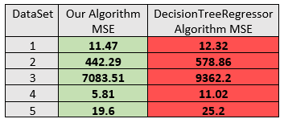

In the course of the work, a decision tree algorithm was developed, in which all nodes and leaves contain a linear regression model

The algorithm showed good results, showing MSE better than the DecisionTreeRegressor from SkLearn on different five datasets

The main disadvantages of the algorithm is the calculation time.